# KNN Classification

Shriya Bande

2023-09-30

#Importing required packages

#install.packages(“FNN”) #install.packages(“psych”)

```r
library(psych)
library(FNN)
library(ISLR)
library(class)
library(caret)
library(caTools)
```

#Importing dataset

```r
universalbank<- read.csv("C:/Users/sband/Downloads/UniversalBank (2).csv")
summary(universalbank)
```

```
##        ID            Age          Experience       Income          ZIP.Code
##  Min.   :   1   Min.   :23.00   Min.   :-3.0   Min.   :  8.00   Min.   : 9307
##  1st Qu.:1251   1st Qu.:35.00   1st Qu.:10.0   1st Qu.: 39.00   1st Qu.:91911
##  Median :2500   Median :45.00   Median :20.0   Median : 64.00   Median :93437
##  Mean   :2500   Mean   :45.34   Mean   :20.1   Mean   : 73.77   Mean   :93153
##  3rd Qu.:3750   3rd Qu.:55.00   3rd Qu.:30.0   3rd Qu.: 98.00   3rd Qu.:94608
##  Max.   :5000   Max.   :67.00   Max.   :43.0   Max.   :224.00   Max.   :96651
##      Family          CCAvg          Education        Mortgage
##  Min.   :1.000   Min.   : 0.000   Min.   :1.000   Min.   :  0.0
##  1st Qu.:1.000   1st Qu.: 0.700   1st Qu.:1.000   1st Qu.:  0.0
##  Median :2.000   Median : 1.500   Median :2.000   Median :  0.0
##  Mean   :2.396   Mean   : 1.938   Mean   :1.881   Mean   : 56.5
##  3rd Qu.:3.000   3rd Qu.: 2.500   3rd Qu.:3.000   3rd Qu.:101.0
##  Max.   :4.000   Max.   :10.000   Max.   :3.000   Max.   :635.0
##  Personal.Loan   Securities.Account   CD.Account         Online
##  Min.   :0.000   Min.   :0.0000     Min.   :0.0000   Min.   :0.0000
##  1st Qu.:0.000   1st Qu.:0.0000     1st Qu.:0.0000   1st Qu.:0.0000
##  Median :0.000   Median :0.0000     Median :0.0000   Median :1.0000
##  Mean   :0.096   Mean   :0.1044     Mean   :0.0604   Mean   :0.5968
##  3rd Qu.:0.000   3rd Qu.:0.0000     3rd Qu.:0.0000   3rd Qu.:1.0000
##  Max.   :1.000   Max.   :1.0000     Max.   :1.0000   Max.   :1.0000
##    CreditCard
##  Min.   :0.000
##  1st Qu.:0.000
##  Median :0.000
##  Mean   :0.294
##  3rd Qu.:1.000
##  Max.   :1.000
```

#Eliminating ZIP code and ID from the dataset

```r
universal_bank=subset(universalbank, select=-c(ID, ZIP.Code ))
summary(universal_bank)
```

```
##       Age          Experience       Income           Family
##  Min.   :23.00   Min.   :-3.0   Min.   :  8.00   Min.   :1.000
##  1st Qu.:35.00   1st Qu.:10.0   1st Qu.: 39.00   1st Qu.:1.000
##  Median :45.00   Median :20.0   Median : 64.00   Median :2.000
##  Mean   :45.34   Mean   :20.1   Mean   : 73.77   Mean   :2.396
##  3rd Qu.:55.00   3rd Qu.:30.0   3rd Qu.: 98.00   3rd Qu.:3.000
##  Max.   :67.00   Max.   :43.0   Max.   :224.00   Max.   :4.000
##      CCAvg          Education        Mortgage     Personal.Loan
##  Min.   : 0.000   Min.   :1.000   Min.   :  0.0   Min.   :0.000
##  1st Qu.: 0.700   1st Qu.:1.000   1st Qu.:  0.0   1st Qu.:0.000
##  Median : 1.500   Median :2.000   Median :  0.0   Median :0.000
##  Mean   : 1.938   Mean   :1.881   Mean   : 56.5   Mean   :0.096
##  3rd Qu.: 2.500   3rd Qu.:3.000   3rd Qu.:101.0   3rd Qu.:0.000
##  Max.   :10.000   Max.   :3.000   Max.   :635.0   Max.   :1.000
##  Securities.Account   CD.Account         Online         CreditCard
##  Min.   :0.0000     Min.   :0.0000   Min.   :0.0000   Min.   :0.000
##  1st Qu.:0.0000     1st Qu.:0.0000   1st Qu.:0.0000   1st Qu.:0.000
##  Median :0.0000     Median :0.0000   Median :1.0000   Median :0.000
##  Mean   :0.1044     Mean   :0.0604   Mean   :0.5968   Mean   :0.294
##  3rd Qu.:0.0000     3rd Qu.:0.0000   3rd Qu.:1.0000   3rd Qu.:1.000
##  Max.   :1.0000     Max.   :1.0000   Max.   :1.0000   Max.   :1.000
```

```r
#converting education into factor
universal_bank$Education = as.factor(universal_bank$Education)

#convert education to dummy variables
groups = dummyVars(~.,data = universal_bank) #this creates dummy groups
universal_bank_df = as.data.frame(predict(groups, universal_bank))
summary(universal_bank_df)
```

```
##       Age          Experience       Income           Family
##  Min.   :23.00   Min.   :-3.0   Min.   :  8.00   Min.   :1.000
##  1st Qu.:35.00   1st Qu.:10.0   1st Qu.: 39.00   1st Qu.:1.000
##  Median :45.00   Median :20.0   Median : 64.00   Median :2.000
##  Mean   :45.34   Mean   :20.1   Mean   : 73.77   Mean   :2.396
##  3rd Qu.:55.00   3rd Qu.:30.0   3rd Qu.: 98.00   3rd Qu.:3.000
##  Max.   :67.00   Max.   :43.0   Max.   :224.00   Max.   :4.000
##      CCAvg         Education.1      Education.2      Education.3
##  Min.   : 0.000   Min.   :0.0000   Min.   :0.0000   Min.   :0.0000
##  1st Qu.: 0.700   1st Qu.:0.0000   1st Qu.:0.0000   1st Qu.:0.0000
##  Median : 1.500   Median :0.0000   Median :0.0000   Median :0.0000
##  Mean   : 1.938   Mean   :0.4192   Mean   :0.2806   Mean   :0.3002
##  3rd Qu.: 2.500   3rd Qu.:1.0000   3rd Qu.:1.0000   3rd Qu.:1.0000
##  Max.   :10.000   Max.   :1.0000   Max.   :1.0000   Max.   :1.0000
##     Mortgage     Personal.Loan   Securities.Account   CD.Account
##  Min.   :  0.0   Min.   :0.000   Min.   :0.0000     Min.   :0.0000
##  1st Qu.:  0.0   1st Qu.:0.000   1st Qu.:0.0000     1st Qu.:0.0000
##  Median :  0.0   Median :0.000   Median :0.0000     Median :0.0000
##  Mean   : 56.5   Mean   :0.096   Mean   :0.1044     Mean   :0.0604
##  3rd Qu.:101.0   3rd Qu.:0.000   3rd Qu.:0.0000     3rd Qu.:0.0000
##  Max.   :635.0   Max.   :1.000   Max.   :1.0000     Max.   :1.0000
##      Online         CreditCard
##  Min.   :0.0000   Min.   :0.000
##  1st Qu.:0.0000   1st Qu.:0.000
##  Median :1.0000   Median :0.000
##  Mean   :0.5968   Mean   :0.294
##  3rd Qu.:1.0000   3rd Qu.:1.000
##  Max.   :1.0000   Max.   :1.000
```

#partitioning the data into training and validation

```r
set.seed(123)
split = sample.split(universal_bank_df, SplitRatio = 0.6)
train.df = subset(universal_bank_df, split == TRUE)
valid.df = subset(universal_bank_df, split == FALSE)

# Print the sizes of the training and validation sets
print(paste("The size of the training set is:", nrow(train.df)))
```

```
## [1] "The size of the training set is: 2857"
```

```r
print(paste("The size of the Validation set is:", nrow(valid.df)))
```

```
## [1] "The size of the Validation set is: 2143"
```

```r
# normalizing the data

train.norm.df = train.df[,-10] #note that personal income is the 10th variable
valid.norm.df = valid.df[,-10]

norm.values = preProcess(train.df[,-10], method=c("center", "scale"))
train.norm.df = predict(norm.values, train.df[,-10])
Valid.norm.df = predict(norm.values, valid.df[,-10])
```

#Question 1 - Age = 40, Experience = 10, Income = 84, Family = 2, CCAvg = 2, Education_1 = 0, Education_2 =1, Education_3 = 0, Mortgage = 0, Securities Account = 0, CD Account = 0, Online = 1, and Credit Card = 1. Perform a k-NN classification with all predictors except ID and ZIP codeusing k = 1. Remember to transform categorical predictors with more than two categoriesinto dummy variables first. Specify the success class as 1 (loan acceptance), and use thedefault cutoff value of 0.5. How would this customer be classified?

```r
new_cust = data.frame(
  Age = 40,
  Experience = 10,
  Income = 84,
  Family = 2,
  CCAvg = 2,
  Education.1 = 0,
  Education.2 = 1,
  Education.3 = 0,
  Mortgage = 0,
  `Securities.Account` = 0,
  CD.Account = 0,
  Online = 1,
  `CreditCard` = 1
)
new_cust
```

```
##   Age Experience Income Family CCAvg Education.1 Education.2 Education.3
## 1  40         10     84      2     2           0           1           0
##   Mortgage Securities.Account CD.Account Online CreditCard
## 1        0                  0          0      1          1
```

```r
# Normalize the new_cust
new.cust.norm = new_cust
new.cust.norm = predict(norm.values, new.cust.norm)
```

```r
knn1 = class::knn(train = train.norm.df, test = new.cust.norm, cl = train.df$Personal.Loan, k = 1)
knn1
```

```
## [1] 0
## Levels: 0 1
```

#based on the kNN algorithm with a k value of 1 (i.e., considering only the nearest neighbor), the algorithm predicts that the new customer is in the class labeled “0.” which means loan is not accpeted.

```r
# Question 2- What is a choice of k that balances between overfitting and ignoring the predictor information?

accuracy.diff <- data.frame(k = seq(1, 15, 1), overallaccuracy = rep(0, 15))
for(i in 1:15) {
  KNN.Pred <- class::knn(train = train.norm.df,
                         test = Valid.norm.df,
                         cl = train.df$Personal.Loan, k = i)
  accuracy.diff[i, 2] <- confusionMatrix(KNN.Pred,
                                    as.factor(valid.df$Personal.Loan),positive = "1")$overall[1]
}

which(accuracy.diff[,2] == max(accuracy.diff[,2]))
```

```
## [1] 3
```

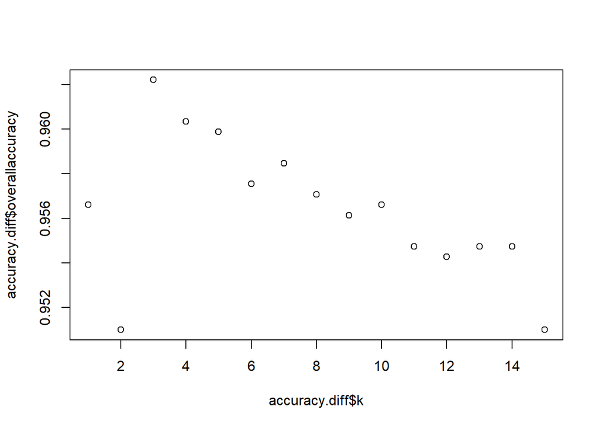

```r
plot(accuracy.diff$k,accuracy.diff$overallaccuracy)
```

# The best K is 3

# Question 3 - Show the confusion matrix for the validation data that results from using the best k

```r
# Best k value
best_k <- 3

# Train the kNN model with the best k
best_knn <- class::knn(train = train.norm.df,
                        test = Valid.norm.df,
                        cl = train.df$Personal.Loan, k = best_k)

# Create the confusion matrix
confusion_matrix <- confusionMatrix(best_knn, as.factor(valid.df$Personal.Loan))

# Display the confusion matrix
print("Confusion Matrix:")
```

```
## [1] "Confusion Matrix:"
```

```r
print(confusion_matrix)
```

```
## Confusion Matrix and Statistics
##
##           Reference
## Prediction    0    1
##          0 1947   70
##          1   11  115
##
##                Accuracy : 0.9622
##                  95% CI : (0.9532, 0.9699)
##     No Information Rate : 0.9137
##     P-Value [Acc > NIR] : < 2.2e-16
##
##                   Kappa : 0.72
##
##  Mcnemar's Test P-Value : 1.16e-10
##
##             Sensitivity : 0.9944
##             Specificity : 0.6216
##          Pos Pred Value : 0.9653
##          Neg Pred Value : 0.9127
##              Prevalence : 0.9137
##          Detection Rate : 0.9085
##    Detection Prevalence : 0.9412
##       Balanced Accuracy : 0.8080
##
##        'Positive' Class : 0
##
```

#Question 4: - Consider the following customer: Age = 40, Experience = 10, Income = 84, Family = 2, CCAvg = 2, Education_1 = 0, Education_2 = 1, Education_3 = 0, Mortgage = 0, Securities Account = 0, CD Account = 0, Online = 1 and Credit Card = 1. Classify the customer using the best k.

```r
# Customer data
new_cust <- data.frame(
  Age = 40,
  Experience = 10,
  Income = 84,
  Family = 2,
  CCAvg = 2,
  Education.1 = 0,
  Education.2 = 1,
  Education.3 = 0,
  Mortgage = 0,
  `Securities.Account` = 0,
  CD.Account = 0,
  Online = 1,
  `CreditCard` = 1
)

# Normalize the customer data
new_cust.norm <- predict(norm.values, new_cust)

# Classify the customer using the best k (k = 3)
customer_classification <- class::knn(train = train.norm.df,
                                      test = new_cust.norm,
                                      cl = train.df$Personal.Loan,
                                      k = best_k)

# Display the classification result
if (customer_classification == 1) {
  cat("The customer is classified as 'Accepted (1)' for a personal loan.\n")
} else {
  cat("The customer is classified as 'Not Accepted (0)' for a personal loan.\n")
}
```

```
## The customer is classified as 'Not Accepted (0)' for a personal loan.
```

# Question 5- Repartition the data, this time into training, validation, and test sets (50% : 30% : 20%). Apply

the k-NN method with the k chosen above. Compare the confusion matrix of the test set with that of the training and validation sets. Comment on the differences and their reason.

```r
# Partition the data into training, validation, and test sets (50% : 30% : 20%)
set.seed(123)
split1 <- sample.split(universal_bank_df, SplitRatio = 0.5)
train_valid.df <- subset(universal_bank_df, split1 == TRUE)
valid_test.df <- subset(universal_bank_df, split1 == FALSE)

# Further split the combined validation and test data into 30% validation and 20% test
split2 <- sample.split(valid_test.df, SplitRatio = 0.6)
valid.df <- subset(valid_test.df, split2 == TRUE)
test.df <- subset(valid_test.df, split2 == FALSE)

# Print the sizes of the training, validation, and test sets
print(paste("The size of the training set is:", nrow(train_valid.df)))
```

```
## [1] "The size of the training set is: 2500"
```

```r
print(paste("The size of the Validation set is:", nrow(valid.df)))
```

```
## [1] "The size of the Validation set is: 1428"
```

```r
print(paste("The size of the Test set is:", nrow(test.df)))
```

```
## [1] "The size of the Test set is: 1072"
```

```r
# Normalize the data
norm.values <- preProcess(train_valid.df[, -10], method = c("center", "scale"))
train_valid.norm.df <- predict(norm.values, train_valid.df[, -10])
valid.norm.df <- predict(norm.values, valid.df[, -10])
test.norm.df <- predict(norm.values, test.df[, -10])

# Define the best k value
best_k <- 3

# Train the k-NN model with the best k using the training set
best_knn_train <- class::knn(train = train_valid.norm.df,
                              test = train_valid.norm.df,
                              cl = train_valid.df$Personal.Loan,
                              k = best_k)

# Create the confusion matrix for the training set
confusion_matrix_train <- confusionMatrix(best_knn_train, as.factor(train_valid.df$Personal.Loan))

# Train the k-NN model with the best k using the validation set
best_knn_valid <- class::knn(train = train_valid.norm.df,
                              test = valid.norm.df,
                              cl = train_valid.df$Personal.Loan,
                              k = best_k)

# Create the confusion matrix for the validation set
confusion_matrix_valid <- confusionMatrix(best_knn_valid, as.factor(valid.df$Personal.Loan))

# Train the k-NN model with the best k using the test set
best_knn_test <- class::knn(train = train_valid.norm.df,
                             test = test.norm.df,
                             cl = train_valid.df$Personal.Loan,
                             k = best_k)

# Create the confusion matrix for the test set
confusion_matrix_test <- confusionMatrix(best_knn_test, as.factor(test.df$Personal.Loan))

# Display the confusion matrices and their differences
print("Confusion Matrix for Training Set:")
```

```
## [1] "Confusion Matrix for Training Set:"
```

```r
print(confusion_matrix_train)
```

```
## Confusion Matrix and Statistics
##
##           Reference
## Prediction    0    1
##          0 2235   48
##          1    6  211
##
##                Accuracy : 0.9784
##                  95% CI : (0.9719, 0.9837)
##     No Information Rate : 0.8964
##     P-Value [Acc > NIR] : < 2.2e-16
##
##                   Kappa : 0.8747
##
##  Mcnemar's Test P-Value : 2.414e-08
##
##             Sensitivity : 0.9973
##             Specificity : 0.8147
##          Pos Pred Value : 0.9790
##          Neg Pred Value : 0.9724
##              Prevalence : 0.8964
##          Detection Rate : 0.8940
##    Detection Prevalence : 0.9132
##       Balanced Accuracy : 0.9060
##
##        'Positive' Class : 0
##
```

```r
print("Confusion Matrix for Validation Set:")
```

```
## [1] "Confusion Matrix for Validation Set:"
```

```r
print(confusion_matrix_valid)
```

```
## Confusion Matrix and Statistics
##
##           Reference
## Prediction    0    1
##          0 1301   41
##          1    6   80
##
##                Accuracy : 0.9671
##                  95% CI : (0.9565, 0.9757)
##     No Information Rate : 0.9153
##     P-Value [Acc > NIR] : 1.732e-15
##
##                   Kappa : 0.7557
##
##  Mcnemar's Test P-Value : 7.071e-07
##
##             Sensitivity : 0.9954
##             Specificity : 0.6612
##          Pos Pred Value : 0.9694
##          Neg Pred Value : 0.9302
##              Prevalence : 0.9153
##          Detection Rate : 0.9111
##    Detection Prevalence : 0.9398
##       Balanced Accuracy : 0.8283
##
##        'Positive' Class : 0
##
```

```r
print("Confusion Matrix for Test Set:")
```

```
## [1] "Confusion Matrix for Test Set:"
```

```r
print(confusion_matrix_test)
```

```
## Confusion Matrix and Statistics
##
##           Reference
## Prediction   0   1
##          0 965  38
##          1   7  62
##
##                Accuracy : 0.958
##                  95% CI : (0.9442, 0.9692)
##     No Information Rate : 0.9067
##     P-Value [Acc > NIR] : 1.186e-10
##
##                   Kappa : 0.7118
##
##  Mcnemar's Test P-Value : 7.744e-06
##
##             Sensitivity : 0.9928
##             Specificity : 0.6200
##          Pos Pred Value : 0.9621
##          Neg Pred Value : 0.8986
##              Prevalence : 0.9067
##          Detection Rate : 0.9002
##    Detection Prevalence : 0.9356
##       Balanced Accuracy : 0.8064
##
##        'Positive' Class : 0
##
```